# Betke-Briana-ADA-homework-4

Briana Betke

5/8/2020

# Homework 4

Starting with reading in the packages needed for the assignment:

```r
library(tidyverse)
library(patchwork) # for plotting
library(scales) # for log y axis scale
library(collapse) # for `fmode()` to find mode
library(BBmisc) # for %nin%
library(devtools)
library(tidycovid19)
```

run the function provided:

```r
merged <- download_merged_data(cached = TRUE)
merged <- merged %>%
  group_by(country, iso3c) %>%
  arrange(country, iso3c, date) %>%
  mutate(
    daily_confirmed = confirmed - lag(confirmed, n = 1),
    daily_deaths = deaths - lag(deaths, n = 1),
    daily_recovered = recovered - lag(recovered, n = 1)
  ) %>%
  mutate(
    daily_confirmed = replace_na(daily_confirmed, 0),
    daily_deaths = replace_na(daily_deaths, 0),
    daily_recovered = replace_na(daily_recovered, 0)
  ) %>%
  ungroup() %>%
  arrange(country, iso3c, date)

add_world1 <- merged %>%
  group_by(date) %>%
  arrange(date) %>%
  summarize(
    country = "World", iso3c = NA, confirmed = sum(confirmed, na.rm = TRUE),
    deaths = sum(deaths, na.rm = TRUE), recovered = sum(recovered, na.rm = TRUE),
    timestamp = fmode(timestamp)
  ) %>%
  mutate(
    daily_confirmed = confirmed - lag(confirmed, n = 1),
    daily_deaths = deaths - lag(deaths, n = 1),
    daily_recovered = recovered - lag(recovered, n = 1)
  ) %>%
  mutate(
    daily_confirmed = replace_na(daily_confirmed, 0),
    daily_deaths = replace_na(daily_deaths, 0),
    daily_recovered = replace_na(daily_recovered, 0)
  ) %>%
  ungroup() %>%
  arrange(country, iso3c, date)

add_world2 <- merged %>%
  group_by(country, iso3c) %>%
  summarize(
    population = fmode(population),
    land_area_skm = fmode(land_area_skm),
    timestamp = fmode(timestamp)
  ) %>%
  ungroup() %>%
  summarize(
    country = "World", iso3c = NA,
    population = sum(population, na.rm = TRUE),
    land_area_skm = sum(land_area_skm, na.rm = TRUE)
  ) %>%
  mutate(pop_density = population / land_area_skm)

add_world <- left_join(add_world1, add_world2, by = c("country", "iso3c"))
merged <- bind_rows(merged, add_world)

cv_data <- pivot_longer(merged,
  cols = c(
    "confirmed", "deaths", "recovered",
    "daily_confirmed", "daily_deaths", "daily_recovered"
  ),
  names_to = "variable", values_to = "cases"
) %>%
  arrange(country, variable, date) %>%
  rename(area = land_area_skm, density = pop_density) %>%
  mutate(rate = cases / population * 10^6) %>%
  ## new code to omit data before 2020-05-11
  filter(date < "2020-05-11")
## end of new code
```

Now the function:

```r
cv_summary <- function(d, country_list = "World",
                       plot = TRUE, facet = "country",
                       status = c("confirmed", "deaths", "recovered")) {

  # based on `wes_palettes()` color schemes GrandBudapest1, IsleofDogs1,
  # IsleofDogs2 from the {wesanderson} package
  my_palette <- c(
    "#5B1A18", "#FD6467", "#F1BB7B", "#D67236",
    "#0F0D0E", "#9986A5", "#79402E", "#CCBA72", "#D9D0D3", "#8D8680",
    "#EAD3BF", "#AA9486", "#B6854D", "#39312F", "#1C1718"
  )

  if (facet == "country") {
    fill <- "variable"
    n <- length(unique(d$variable)) / 2
    # need only half of unique # of variable (3)
  }

  if (facet == "variable") {
    fill <- "country"
    n <- length(country_list)
    # need number of countries
  }

  if ("All" %in% country_list) {
    country_list <- unique(d$country)
    country_list <- setdiff(country_list, "World")
  }

  if ("World" %in% country_list) {
    d <- d %>% filter(country %in% country_list)

    totals <- d %>%
      group_by(variable) %>%
      summarize(
        country = "World",
        cases = max(cases),
        population = max(population),
        area = max(area),
        density = max(density),
        rate = max(rate, na.rm = TRUE),
        on = max(date)
      ) %>%
      select(country, variable, cases, population, area, density, rate, on) %>%
      arrange(variable) %>%
      ungroup()
  }

  if ("World" %nin% country_list) {
    d <- d %>% filter(country %in% country_list)
    totals <- d %>%
      group_by(country, variable) %>%
      summarize(
        cases = max(cases),
        population = max(population),
        area = max(area),
        density = max(density),
        rate = max(rate, na.rm = TRUE),
        on = max(date),
        gdp_capita = fmode(gdp_capita),
        income = fmode(income),
        life_expectancy = fmode(life_expectancy),
        max_sd = max(soc_dist),
        max_mr = max(mov_rest)
      ) %>%
      select(
        country, variable, cases, population, area, density, rate,
        gdp_capita, income, life_expectancy, max_sd, max_mr, on
      ) %>%
      arrange(country, variable) %>%
      ungroup()
  }

  if (plot == TRUE) {
    cc <- filter(d, variable %in% status)
    cum_cases_plot <- ggplot(
      data = cc,
      # use the tidy evaluation pronoun .data to slice the chosen fill
      # variable from the data frame
      aes(
        x = date, y = cases + 1, color = .data[[fill]],
        fill = .data[[fill]]
      )
    ) +
      geom_point(size = 0.5) +
      geom_line() +
      # use the tidy evaluation pronoun .data to slice the chosen facet_wrap
      # variable from the data frame
      facet_wrap(~ .data[[facet]], ncol = 5) +
      xlab("Date") +
      ylab("Log Cumulative Cases") +
      scale_y_log10(
        breaks = trans_breaks("log10", function(x) 10^x),
        labels = trans_format("log10", math_format(10^.x))
      ) +
      scale_color_manual(
        aesthetics = c("color", "fill"),
        name = NULL, values = my_palette
      )

    dc <- filter(d, variable %in% paste0("daily_", status))
    daily_cases_plot <- ggplot(
      data = dc,
      aes(
        x = date, y = cases, color = .data[[fill]],
        fill = .data[[fill]]
      )
    ) +
      geom_point(size = 0.5) +
      geom_line() +
      facet_wrap(~ .data[[facet]], ncol = 5) +
      xlab("Date") +
      ylab("Daily Cases") +
      scale_color_manual(
        aesthetics = c("color", "fill"),
        name = NULL, values = my_palette
      )
  }

  if (plot == TRUE) {
    return(list(
      totals = totals,
      cum_cases_plot = cum_cases_plot,
      daily_cases_plot = daily_cases_plot
    ))
  } else {
    return(list(totals = totals))
  }
}
```

### Challenge 1

Plot global data on confirmed coronavirus infections, deaths, and recoveries with the function.

```r
results <- cv_summary(cv_data, country_list = "World")
results
```

```
## $totals
## # A tibble: 6 x 8
##   country variable          cases population      area density   rate on
##   <chr>   <chr>             <dbl>      <dbl>     <dbl>   <dbl>  <dbl> <date>
## 1 World   confirmed       4100108 7525907933    1.27e8    59.4 545.   2020-05-10
## 2 World   daily_confirmed   99113 7525907933    1.27e8    59.4  13.2  2020-05-10
## 3 World   daily_deaths       8856 7525907933    1.27e8    59.4   1.18 2020-05-10
## 4 World   daily_recovered   65439 7525907933    1.27e8    59.4   8.70 2020-05-10
## 5 World   deaths           282666 7525907933    1.27e8    59.4  37.6  2020-05-10
## 6 World   recovered       1407676 7525907933    1.27e8    59.4 187.   2020-05-10
##
## $cum_cases_plot
```

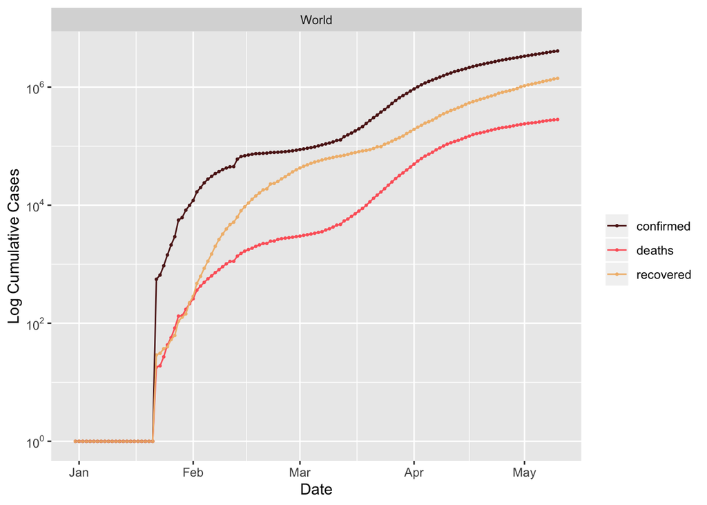

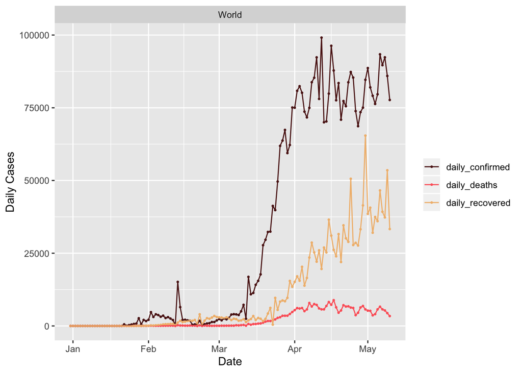

### Challenge 2

Plot data on confirmed coronavirus infections, deaths, and recoveries for the G7 countries plus China, Russia, and Iran. Facet by country, then variable.

```r
# make a list of countries
countries <- list("United States", "United Kingdom", "Canada", "France", "Germany", "Italy", "Japan", "China", "Russia", "Iran")

# by country
cv_summary(cv_data, country_list = countries, facet = "country")
```

```
## $totals
## # A tibble: 60 x 13
##    country variable cases population   area density    rate gdp_capita income
##    <chr>   <chr>    <dbl>      <dbl>  <dbl>   <dbl>   <dbl>      <dbl> <chr>
##  1 Canada  confirm… 70091   37057765 9.09e6    4.08 1.89e+3     51392. High …
##  2 Canada  daily_c…  2778   37057765 9.09e6    4.08 7.50e+1     51392. High …
##  3 Canada  daily_d…   251   37057765 9.09e6    4.08 6.77e+0     51392. High …
##  4 Canada  daily_r…  1385   37057765 9.09e6    4.08 3.74e+1     51392. High …
##  5 Canada  deaths    4991   37057765 9.09e6    4.08 1.35e+2     51392. High …
##  6 Canada  recover… 32109   37057765 9.09e6    4.08 8.66e+2     51392. High …
##  7 China   confirm…    NA 1392730000 9.39e6  148.   6.03e+1      7753. Upper…
##  8 China   daily_c… 15136 1392730000 9.39e6  148.   1.09e+1      7753. Upper…
##  9 China   daily_d…  1290 1392730000 9.39e6  148.   9.26e-1      7753. Upper…
## 10 China   daily_r…  3995 1392730000 9.39e6  148.   2.87e+0      7753. Upper…
## # … with 50 more rows, and 4 more variables: life_expectancy <dbl>,
## #   max_sd <dbl>, max_mr <dbl>, on <date>
##
## $cum_cases_plot
```

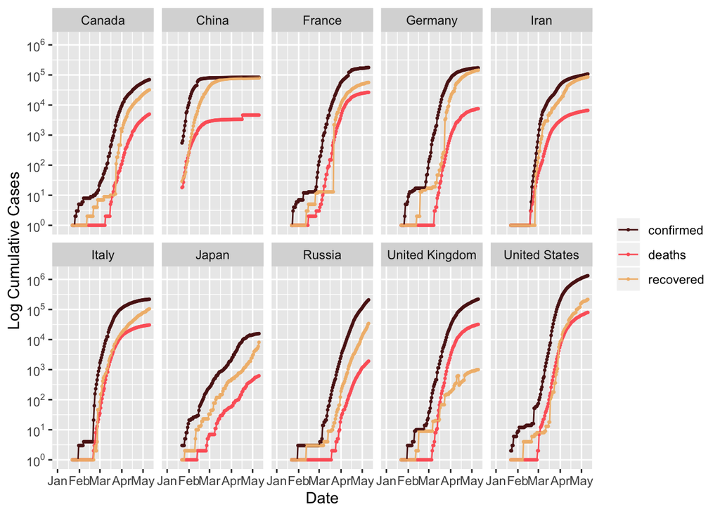

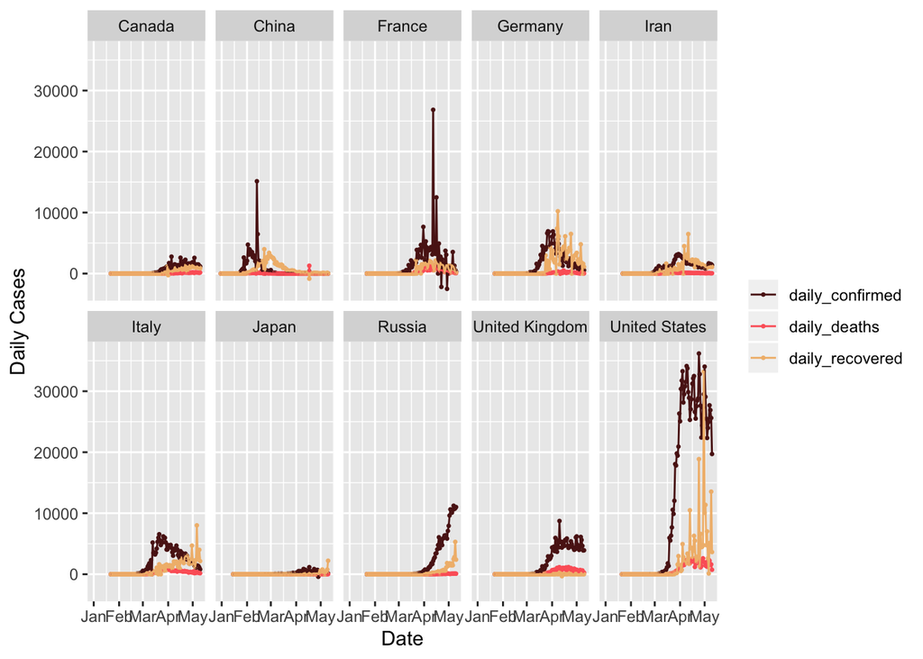

```r
# by variable
cv_summary(cv_data, country_list = countries, facet = "variable")
```

```
## $totals
## # A tibble: 60 x 13
##    country variable cases population   area density    rate gdp_capita income
##    <chr>   <chr>    <dbl>      <dbl>  <dbl>   <dbl>   <dbl>      <dbl> <chr>
##  1 Canada  confirm… 70091   37057765 9.09e6    4.08 1.89e+3     51392. High …
##  2 Canada  daily_c…  2778   37057765 9.09e6    4.08 7.50e+1     51392. High …
##  3 Canada  daily_d…   251   37057765 9.09e6    4.08 6.77e+0     51392. High …
##  4 Canada  daily_r…  1385   37057765 9.09e6    4.08 3.74e+1     51392. High …
##  5 Canada  deaths    4991   37057765 9.09e6    4.08 1.35e+2     51392. High …
##  6 Canada  recover… 32109   37057765 9.09e6    4.08 8.66e+2     51392. High …
##  7 China   confirm…    NA 1392730000 9.39e6  148.   6.03e+1      7753. Upper…
##  8 China   daily_c… 15136 1392730000 9.39e6  148.   1.09e+1      7753. Upper…
##  9 China   daily_d…  1290 1392730000 9.39e6  148.   9.26e-1      7753. Upper…
## 10 China   daily_r…  3995 1392730000 9.39e6  148.   2.87e+0      7753. Upper…
## # … with 50 more rows, and 4 more variables: life_expectancy <dbl>,
## #   max_sd <dbl>, max_mr <dbl>, on <date>
##
## $cum_cases_plot
```

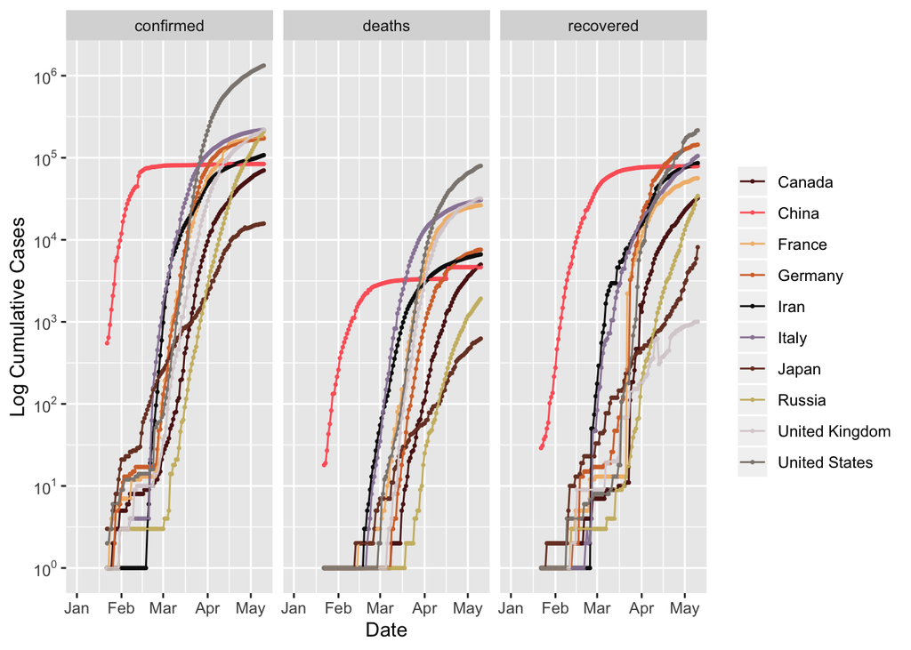

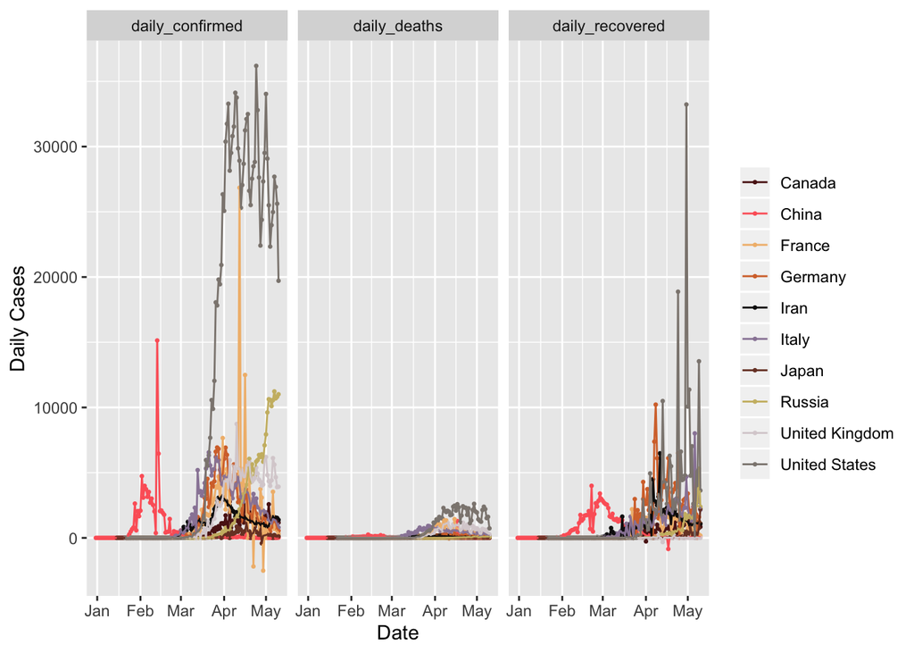

### Challenge 3

Get the summary for all countries then filter for countries with a population over 1 million. Get the number of countires.

```r
results2 <- cv_summary(cv_data, country_list = "All", plot = FALSE)
All <- results2$totals

# Tibble called d of countries with a population over 1 million
d <- filter(All, population > 1000000)

# I used the table function then got the lenght of the table. I know using the unique function in place of the table gives the same number.
length(table(d$country))
```

```
## [1] 155
```

According to the output, there are 155 countries with populations greater than 1 million in this dataset.

### Challenge 4

Create two datasets from d

```r
# Make the overall tibble
overall <- filter(d, variable == "confirmed")
head(overall, 3)
```

```
## # A tibble: 3 x 13
##   country variable cases population   area density  rate gdp_capita income
##   <chr>   <chr>    <dbl>      <dbl>  <dbl>   <dbl> <dbl>      <dbl> <chr>
## 1 Afghan… confirm…  4402   37172386 6.53e5    56.9  118.       564. Low i…
## 2 Albania confirm…   868    2866376 2.74e4   105.   303.      5079. Upper…
## 3 Algeria confirm…  5723   42228429 2.38e6    17.7  136.      4764. Upper…
## # … with 4 more variables: life_expectancy <dbl>, max_sd <dbl>, max_mr <dbl>,
## #   on <date>
```

```r
# Make the daily tibble
daily <- filter(d, variable == "daily_confirmed")
head(daily, 3)
```

```
## # A tibble: 3 x 13
##   country variable cases population   area density  rate gdp_capita income
##   <chr>   <chr>    <dbl>      <dbl>  <dbl>   <dbl> <dbl>      <dbl> <chr>
## 1 Afghan… daily_c…   369   37172386 6.53e5    56.9  9.93       564. Low i…
## 2 Albania daily_c…    34    2866376 2.74e4   105.  11.9       5079. Upper…
## 3 Algeria daily_c…   199   42228429 2.38e6    17.7  4.71      4764. Upper…
## # … with 4 more variables: life_expectancy <dbl>, max_sd <dbl>, max_mr <dbl>,
## #   on <date>
```

Which 10 countries have exprienced the highest rate of confirmed cases?

```r
rate_All <- overall %>% arrange(desc(rate))
head(rate_All, 10)
```

```
## # A tibble: 10 x 13
##    country variable  cases population   area density  rate gdp_capita income
##    <chr>   <chr>     <dbl>      <dbl>  <dbl>   <dbl> <dbl>      <dbl> <chr>
##  1 Qatar   confirm…  22520    2781677 1.16e4   240.  8096.     63261. High …
##  2 Spain   confirm… 224350   46796540 5.00e5    93.5 4794.     32950. High …
##  3 Ireland confirm…  22996    4867309 6.89e4    70.5 4725.     76881. High …
##  4 Belgium confirm…  53081   11433256 3.03e4   377.  4643.     47166. High …
##  5 Singap… confirm…  23336    5638676 7.09e2  7953.  4139.     58248. High …
##  6 United… confirm…     NA  326687501 9.15e6    35.8 4069.     54579. High …
##  7 Italy   confirm… 219070   60421760 2.94e5   205.  3626.     35432. High …
##  8 Switze… confirm…  30305    8513227 3.95e4   216.  3560.     79214. High …
##  9 United… confirm… 220449   66460344 2.42e5   275.  3317.     43325. High …
## 10 Bahrain confirm…   4941    1569439 7.78e2  2017.  3148.     21438. High …
## # … with 4 more variables: life_expectancy <dbl>, max_sd <dbl>, max_mr <dbl>,
## #   on <date>
```

Which 10 countries expericence the highest single day rate of confirmed cases?

```r
rate_Daily <- daily %>% arrange(desc(rate))
head(rate_Daily, 10)
```

```
## # A tibble: 10 x 13
##    country variable cases population   area density  rate gdp_capita income
##    <chr>   <chr>    <dbl>      <dbl>  <dbl>   <dbl> <dbl>      <dbl> <chr>
##  1 Ecuador daily_c… 11536   17084357 2.48e5    68.8  675.      5185. Upper…
##  2 Qatar   daily_c…  1311    2781677 1.16e4   240.   471.     63261. High …
##  3 France  daily_c… 26849   66977107 5.48e5   122.   401.     43664. High …
##  4 Ireland daily_c…  1515    4867309 6.89e4    70.5  311.     76881. High …
##  5 Kuwait  daily_c…  1065    4137309 1.78e4   232.   257.     33112. High …
##  6 Singap… daily_c…  1426    5638676 7.09e2  7953.   253.     58248. High …
##  7 Belgium daily_c…  2454   11433256 3.03e4   377.   215.     47166. High …
##  8 Bahrain daily_c…   330    1569439 7.78e2  2017.   210.     21438. High …
##  9 Spain   daily_c…  9630   46796540 5.00e5    93.5  206.     32950. High …
## 10 Belarus daily_c…  1485    9483499 2.03e5    46.7  157.      6744. Upper…
## # … with 4 more variables: life_expectancy <dbl>, max_sd <dbl>, max_mr <dbl>,
## #   on <date>
```

### Challenge 5

Running a linear model with overall rate as the response and density, population, gdp, and income as predictors.

Visualizing the variables for overall:

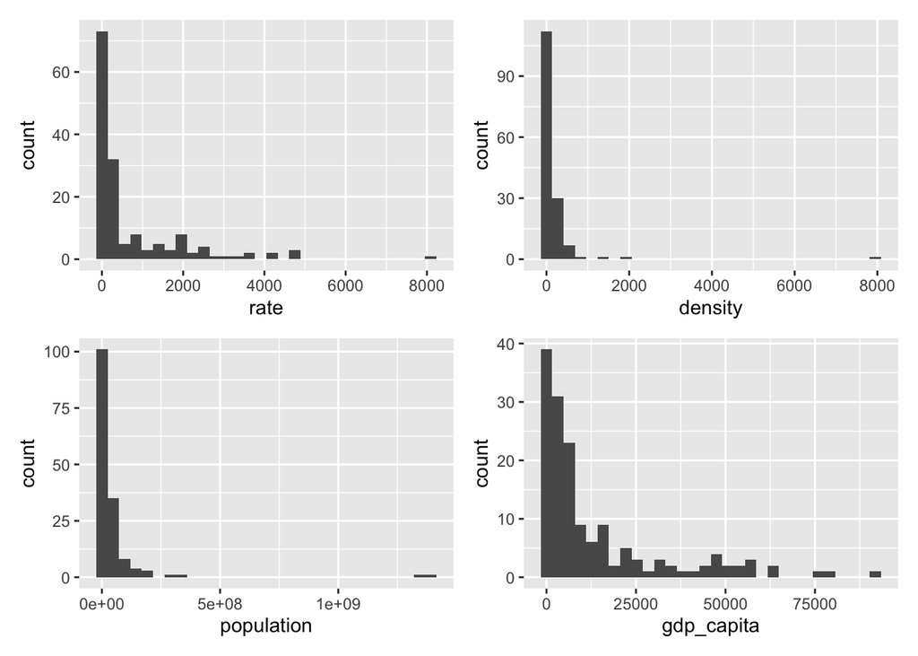

```r
# Set up the histograpms with ggplot
rate_gg <- ggplot(overall, aes(x=rate)) + geom_histogram()
density_gg <- ggplot(overall, aes(x=density)) + geom_histogram()
pop_gg <- ggplot(overall, aes(x=population)) + geom_histogram()
gdp_gg <- ggplot(overall, aes(x=gdp_capita)) + geom_histogram()

# Make multiplot with patcwork since its already read in.
(rate_gg | density_gg)/(pop_gg | gdp_gg)
```

Numeric variables with transformations:

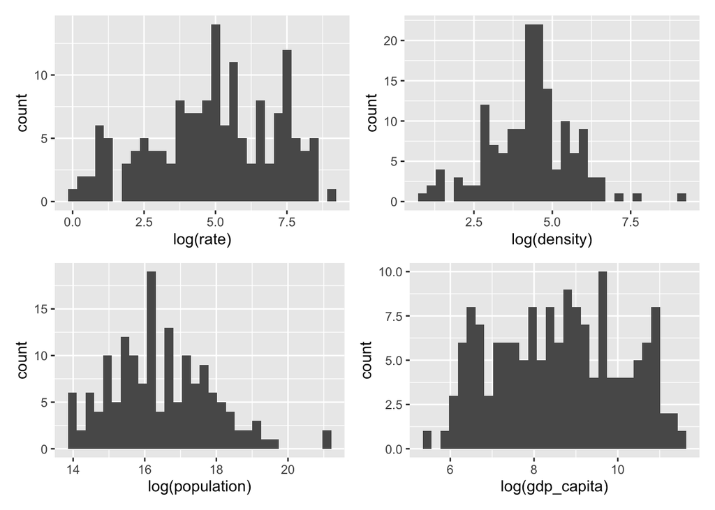

```r
log_rate_gg <- ggplot(overall, aes(x=log(rate))) + geom_histogram()
log_density_gg <- ggplot(overall, aes(x=log(density))) + geom_histogram()
log_pop_gg <- ggplot(overall, aes(x=log(population))) + geom_histogram()
log_gdp_gg <- ggplot(overall, aes(x=log(gdp_capita))) + geom_histogram()

(log_rate_gg | log_density_gg)/(log_pop_gg | log_gdp_gg)
```

Run the model:

```r
overall_NA <- overall %>% drop_na()
# dataset without the value of zero in rate
overall_NA <- filter(overall_NA, rate > 0)
overall_NA$income <- as.factor(overall_NA$income)

mod <- lm(log(rate) ~ log(density) + log(population) + log(gdp_capita) + income, data = overall_NA)
summary(mod)
```

```
##
## Call:
## lm(formula = log(rate) ~ log(density) + log(population) + log(gdp_capita) +
##     income, data = overall_NA)
##
## Residuals:
##     Min      1Q  Median      3Q     Max
## -3.3734 -0.8119  0.0342  0.8945  3.6321
##
## Coefficients:
##                           Estimate Std. Error t value Pr(>|t|)
## (Intercept)               -4.56025    2.97891  -1.531 0.128114
## log(density)               0.26175    0.08886   2.946 0.003789 **
## log(population)            0.01215    0.09006   0.135 0.892848
## log(gdp_capita)            0.99544    0.26381   3.773 0.000239 ***
## incomeLow income          -0.40556    1.09844  -0.369 0.712541
## incomeLower middle income -0.85897    0.78738  -1.091 0.277222
## incomeUpper middle income -0.04759    0.50746  -0.094 0.925415
## ---
## Signif. codes:  0 '***' 0.001 '**' 0.01 '*' 0.05 '.' 0.1 ' ' 1
##
## Residual standard error: 1.382 on 137 degrees of freedom
## Multiple R-squared:  0.6302, Adjusted R-squared:  0.614
## F-statistic: 38.91 on 6 and 137 DF,  p-value: < 2.2e-16
```

There is evidence, according to this model that density and gdp_capita have slopes that are significantly different than 0.

### Challenge 6

Stepwise selection with AIC find which model is preferred and do this also for the daily infection rates.

```r
# Read in MASS and MuMIn
library(MASS)
library(MuMIn)

# running model selection from the model, called mod, defined in challenge 5
(s <- stepAIC(mod, scope = . ~ ., direction = "both"))
```

```
## Start:  AIC=99.99
## log(rate) ~ log(density) + log(population) + log(gdp_capita) +
##     income
##
##                   Df Sum of Sq    RSS     AIC
## - log(population)  1    0.0348 261.67  98.005
## - income           3    9.8487 271.48  99.307
## <none>                         261.63  99.986
## - log(density)     1   16.5699 278.20 106.829
## - log(gdp_capita)  1   27.1903 288.82 112.224
##
## Step:  AIC=98.01
## log(rate) ~ log(density) + log(gdp_capita) + income
##
##                   Df Sum of Sq    RSS     AIC
## - income           3    9.9253 271.59  97.366
## <none>                         261.67  98.005
## + log(population)  1    0.0348 261.63  99.986
## - log(density)     1   16.9470 278.61 105.042
## - log(gdp_capita)  1   27.7014 289.37 110.496
##
## Step:  AIC=97.37
## log(rate) ~ log(density) + log(gdp_capita)
##
##                   Df Sum of Sq    RSS     AIC
## <none>                         271.59  97.366
## + income           3      9.93 261.67  98.005
## + log(population)  1      0.11 271.48  99.307
## - log(density)     1     16.03 287.62 103.623
## - log(gdp_capita)  1    415.14 686.74 228.948
```

```
##
## Call:
## lm(formula = log(rate) ~ log(density) + log(gdp_capita), data = overall_NA)
##
## Coefficients:
##     (Intercept)     log(density)  log(gdp_capita)
##         -5.9456           0.2529           1.1496
```

```r
# for the full model
r.squaredGLMM(mod)
```

```
##            R2m       R2c
## [1,] 0.6201434 0.6201434
```

```r
# for the best model
best <- lm(log(rate) ~ log(density) + log(gdp_capita), data = overall_NA)
r.squaredGLMM(best)
```

```
##            R2m       R2c
## [1,] 0.6127722 0.6127722
```

Best model has lower R2 value than the full model.

Now to repeat with daily data:

```r
# having trouble with running model with transformation
daily <- filter(daily, rate > 0)
daily$income <- as.factor(daily$income)

# Run the model
mod_daily <- lm(log(rate) ~ log(density) + log(population) + log(gdp_capita) + income, data = daily)
summary(mod_daily)
```

```
##
## Call:
## lm(formula = log(rate) ~ log(density) + log(population) + log(gdp_capita) +
##     income, data = daily)
##
## Residuals:
##     Min      1Q  Median      3Q     Max
## -3.1394 -0.7981 -0.0502  0.8167  4.0482
##
## Coefficients:
##                           Estimate Std. Error t value Pr(>|t|)
## (Intercept)               -2.72076    2.61820  -1.039 0.300491
## log(density)               0.15248    0.07924   1.924 0.056306 .
## log(population)           -0.19245    0.07477  -2.574 0.011081 *
## log(gdp_capita)            0.89562    0.23661   3.785 0.000226 ***
## incomeLow income           0.38518    0.98713   0.390 0.696973
## incomeLower middle income -0.23315    0.70688  -0.330 0.742015
## incomeUpper middle income  0.08670    0.45495   0.191 0.849128
## ---
## Signif. codes:  0 '***' 0.001 '**' 0.01 '*' 0.05 '.' 0.1 ' ' 1
##
## Residual standard error: 1.247 on 142 degrees of freedom
##   (4 observations deleted due to missingness)
## Multiple R-squared:  0.5541, Adjusted R-squared:  0.5353
## F-statistic: 29.41 on 6 and 142 DF,  p-value: < 2.2e-16
```

Variable selection

```r
(s <- stepAIC(mod_daily, scope = . ~ ., direction = "both"))
```

```
## Start:  AIC=72.66
## log(rate) ~ log(density) + log(population) + log(gdp_capita) +
##     income
##
##                   Df Sum of Sq    RSS    AIC
## - income           3    5.4297 226.31 70.274
## <none>                         220.88 72.656
## - log(density)     1    5.7603 226.64 74.492
## - log(population)  1   10.3049 231.18 77.450
## - log(gdp_capita)  1   22.2865 243.16 84.979
##
## Step:  AIC=70.27
## log(rate) ~ log(density) + log(population) + log(gdp_capita)
##
##                   Df Sum of Sq    RSS     AIC
## <none>                         226.31  70.274
## - log(density)     1     5.863 232.17  72.085
## + income           3     5.430 220.88  72.656
## - log(population)  1    12.385 238.69  76.213
## - log(gdp_capita)  1   234.781 461.09 174.317
```

```
##
## Call:
## lm(formula = log(rate) ~ log(density) + log(population) + log(gdp_capita),
##     data = daily)
##
## Coefficients:
##     (Intercept)     log(density)  log(population)  log(gdp_capita)
##         -2.0822           0.1518          -0.2061           0.8523
```

Pseudo r squared

```r
# for the full model
r.squaredGLMM(mod_daily)
```

```
##            R2m       R2c
## [1,] 0.5438461 0.5438461
```

```r
# for the best model
best <- lm(log(rate) ~ log(density) + log(gdp_capita), data = daily)
r.squaredGLMM(best)
```

```
##            R2m       R2c
## [1,] 0.5147306 0.5147306
```

### Challenge 7

First model with both variables added.

```r
daily$max_sd_log1 <- log(daily$max_sd + 1)
daily$max_mr_log1 <- log(daily$max_mr + 1)

best_plus_all <- lm(log(rate) ~ log(density) + log(gdp_capita) + max_sd_log1 + max_mr_log1, data = daily)
summary(best_plus_all)
```

```
##
## Call:
## lm(formula = log(rate) ~ log(density) + log(gdp_capita) + max_sd_log1 +
##     max_mr_log1, data = daily)
##
## Residuals:
##     Min      1Q  Median      3Q     Max
## -3.3258 -0.7373 -0.0401  0.8905  4.1434
##
## Coefficients:
##                 Estimate Std. Error t value Pr(>|t|)
## (Intercept)     -5.24837    0.76767  -6.837 2.13e-10 ***
## log(density)     0.12921    0.07973   1.621    0.107
## log(gdp_capita)  0.87997    0.07298  12.058  < 2e-16 ***
## max_sd_log1      0.05929    0.17582   0.337    0.736
## max_mr_log1     -0.21560    0.16707  -1.290    0.199
## ---
## Signif. codes:  0 '***' 0.001 '**' 0.01 '*' 0.05 '.' 0.1 ' ' 1
##
## Residual standard error: 1.28 on 144 degrees of freedom
##   (4 observations deleted due to missingness)
## Multiple R-squared:  0.5238, Adjusted R-squared:  0.5106
## F-statistic:  39.6 on 4 and 144 DF,  p-value: < 2.2e-16
```

Second model without movement restriction:

```r
best_plus_sd <- lm(log(rate) ~ log(density) + log(gdp_capita) + max_sd_log1, data = daily)
summary(best_plus_sd)
```

```
##
## Call:
## lm(formula = log(rate) ~ log(density) + log(gdp_capita) + max_sd_log1,
##     data = daily)
##
## Residuals:
##     Min      1Q  Median      3Q     Max
## -3.4121 -0.7060 -0.0154  0.8979  4.0786
##
## Coefficients:
##                 Estimate Std. Error t value Pr(>|t|)
## (Intercept)     -5.58604    0.72335  -7.722 1.72e-12 ***
## log(density)     0.12554    0.07986   1.572    0.118
## log(gdp_capita)  0.86978    0.07271  11.962  < 2e-16 ***
## max_sd_log1      0.03719    0.17539   0.212    0.832
## ---
## Signif. codes:  0 '***' 0.001 '**' 0.01 '*' 0.05 '.' 0.1 ' ' 1
##
## Residual standard error: 1.283 on 145 degrees of freedom
##   (4 observations deleted due to missingness)
## Multiple R-squared:  0.5183, Adjusted R-squared:  0.5083
## F-statistic:    52 on 3 and 145 DF,  p-value: < 2.2e-16
```

Third model without social distancing:

```r
best_plus_mr <- lm(log(rate) ~ log(density) + log(gdp_capita) + max_mr_log1, data = daily)
summary(best_plus_mr)
```

```
##
## Call:
## lm(formula = log(rate) ~ log(density) + log(gdp_capita) + max_mr_log1,
##     data = daily)
##
## Residuals:
##     Min      1Q  Median      3Q     Max
## -3.3027 -0.6952 -0.0243  0.8936  4.1112
##
## Coefficients:
##                 Estimate Std. Error t value Pr(>|t|)
## (Intercept)     -5.18849    0.74457  -6.968 1.04e-10 ***
## log(density)     0.12864    0.07947   1.619    0.108
## log(gdp_capita)  0.88504    0.07119  12.432  < 2e-16 ***
## max_mr_log1     -0.21011    0.16577  -1.268    0.207
## ---
## Signif. codes:  0 '***' 0.001 '**' 0.01 '*' 0.05 '.' 0.1 ' ' 1
##
## Residual standard error: 1.276 on 145 degrees of freedom
##   (4 observations deleted due to missingness)
## Multiple R-squared:  0.5234, Adjusted R-squared:  0.5135
## F-statistic: 53.08 on 3 and 145 DF,  p-value: < 2.2e-16
```

Look at AICc table:

```r
library(AICcmodavg)
aic_table <- aictab(list(best_plus_all, best_plus_sd, best_plus_mr),
  modnames = c("best_plus_all", "best_plus_sd", "best_plus_mr"))
aic_table
```

```
##
## Model selection based on AICc:
##
##               K   AICc Delta_AICc AICcWt Cum.Wt      LL
## best_plus_mr  5 501.83       0.00   0.55   0.55 -245.71
## best_plus_sd  5 503.43       1.60   0.25   0.80 -246.51
## best_plus_all 6 503.89       2.05   0.20   1.00 -245.65
```

When looking at AICc, it appears that having one or the other, does improve the model.

### Challenge 8

Set up the dataset:

```r
dat <- cv_data %>% filter(population > 1000000 & rate > 0 & variable == "daily_confirmed")
```

On to the models!

```r
library(lme4) # for the lmer function
# Full model
m1 <- lmer(data = dat, log(rate) ~ log(density) + log(gdp_capita) + soc_dist + mov_rest + (1|country) + (1|date),   REML = FALSE)

# wihtout mov_rest
m2 <- lmer(data = dat, log(rate) ~ log(density) + log(gdp_capita) + soc_dist + (1|country) + (1|date),   REML = FALSE)

# without soc_dist
m3 <- lmer(data = dat, log(rate) ~ log(density) + log(gdp_capita) + (1|country) + (1|date),   REML = FALSE)

# without density
m4 <- lmer(data = dat, log(rate) ~ log(gdp_capita) + soc_dist + mov_rest + (1|country) + (1|date),   REML = FALSE)

# without gdp
m5 <- lmer(data = dat, log(rate) ~ log(density) + soc_dist + mov_rest + (1|country) + (1|date),   REML = FALSE)

# Null model with just random effects
null <- lmer(data = dat, log(rate) ~ (1|country) + (1|date), REML = FALSE)
```

Create and AIC table of the models. Which one is the best model? What is the pseudo r value of that model?

```r
(aic_table <- aictab(list(m1, m2, m3, m4, m5, null),
  modnames = c("m1", "m2", "m3", "m4", "m5", "null")))
```

```
##
## Model selection based on AICc:
##
##      K     AICc Delta_AICc AICcWt Cum.Wt        LL
## m1   8 25434.00       0.00      1      1 -12708.99
## m2   7 25504.84      70.84      0      1 -12745.41
## m4   7 25629.74     195.74      0      1 -12807.86
## m5   7 25719.33     285.33      0      1 -12852.66
## m3   6 25804.34     370.34      0      1 -12896.17
## null 4 26594.08    1160.08      0      1 -13293.04
```

```r
r.squaredGLMM(m1)
```

```
##            R2m       R2c
## [1,] 0.2929222 0.8234002
```

According to the table, the full model has the lowest AICc and the highest Akaike weight of 1.